# Lab #5 - Data Visualization and Machine Learning - Group 4

```python
import pandas as pd
import statsmodels.api as sm
import numpy as np
import matplotlib.pyplot as plt
import seaborn as sns
from sklearn.model_selection import train_test_split, KFold, GridSearchCV
from sklearn.linear_model import LinearRegression
```

### Step 0 : Data Preparation

```python
diamonds_df = pd.read_csv('diamonds.csv')
diamonds_df.head()
```

|  | ID | Carat Weight | Cut | Color | Clarity | Polish | Symmetry | Report | Price |
| --- | --- | --- | --- | --- | --- | --- | --- | --- | --- |
| 0 | 1 | 1.10 | Ideal | H | SI1 | VG | EX | GIA | 5169 |
| 1 | 2 | 0.83 | Ideal | H | VS1 | ID | ID | AGSL | 3470 |
| 2 | 3 | 0.85 | Ideal | H | SI1 | EX | EX | GIA | 3183 |
| 3 | 4 | 0.91 | Ideal | E | SI1 | VG | VG | GIA | 4370 |
| 4 | 5 | 0.83 | Ideal | G | SI1 | EX | EX | GIA | 3171 |

```python
diamonds_df['Cut'].value_counts()
```

```
Ideal              2482
Very Good          2428
Good                708
Signature-Ideal     253
Fair                129
Name: Cut, dtype: int64
```

```python
diamonds_df['Color'].value_counts()
```

```
G    1501
H    1079
F    1013
I     968
E     778
D     661
Name: Color, dtype: int64
```

```python
diamonds_df['Clarity'].value_counts()
```

```
SI1     2059
VS2     1575
VS1     1192
VVS2     666
VVS1     285
IF       219
FL         4
Name: Clarity, dtype: int64
```

```python
diamonds_df['Polish'].value_counts()
```

```
EX    2425
VG    2409
ID     595
G      571
Name: Polish, dtype: int64
```

```python
diamonds_df['Symmetry'].value_counts()
```

```
VG    2417
EX    2059
G      916
ID     608
Name: Symmetry, dtype: int64
```

```python
diamonds_df['Report'].value_counts()
```

```
GIA     5266
AGSL     734
Name: Report, dtype: int64
```

```python
diamonds_df['Carat Weight'].describe()
```

```
count    6000.000000
mean        1.334520
std         0.475696
min         0.750000
25%         1.000000
50%         1.130000
75%         1.590000
max         2.910000
Name: Carat Weight, dtype: float64
```

```python
diamonds_df['Price'].describe()
```

```
count      6000.000000
mean      11791.579333
std       10184.350051
min        2184.000000
25%        5150.500000
50%        7857.000000
75%       15036.500000
max      101561.000000
Name: Price, dtype: float64
```

## Exercise #1: Data Visualization

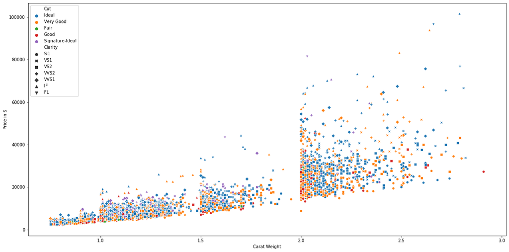

```python
plt.figure(figsize = (20,10))
plot = sns.scatterplot(x='Carat Weight', y='Price', hue="Cut", style="Clarity", data = diamonds_df)
plot = plot.set(ylabel='Price in $', xlabel='Carat Weight')
```

#### Based on the graph it can be seen that nearly for every diamond, with the increase in carat weight, the price increases. However, a gap can be seen in between approx 1.9 - 2.0. As the carat weight increases after 2.0, the price for 'Ideal' cut increases drastically. Also the price of 'Signature-Ideal' is always higher as compared to other cuts for same carat weight. Whereas 'Very Good' cut lies a little lower to 'Ideal' cut prices for same carat weight. The price of 'Good' cut is the lowest among all other cuts.

#### Also, we can find that clarity of 'IF' and 'FL' usually have higher price.

## Exercise #2: Prediction Using OLS Regression

### Step 2.1

#### 'Carat Weight' is continuous.

#### 'Cut', 'Color', 'Clarity', 'Polish', 'Symmetry' are categorical.

```python
cols = ['Carat Weight','Cut', 'Color', 'Clarity', 'Polish', 'Symmetry']
cat_cols = ['Cut', 'Color', 'Clarity', 'Polish', 'Symmetry']
X = pd.get_dummies(diamonds_df[cols], columns=cat_cols, prefix='', prefix_sep='', drop_first=True)
X = sm.add_constant(X)
```

```python
y1 = diamonds_df['Price']/100
pd.concat([X, y1], axis=1).head()
```

|  | const | Carat Weight | Good | Ideal | Signature-Ideal | Very Good | E | F | G | H | ... | VS2 | VVS1 | VVS2 | G | ID | VG | G | ID | VG | Price |
| --- | --- | --- | --- | --- | --- | --- | --- | --- | --- | --- | --- | --- | --- | --- | --- | --- | --- | --- | --- | --- | --- |
| 0 | 1.0 | 1.10 | 0 | 1 | 0 | 0 | 0 | 0 | 0 | 1 | ... | 0 | 0 | 0 | 0 | 0 | 1 | 0 | 0 | 0 | 51.69 |
| 1 | 1.0 | 0.83 | 0 | 1 | 0 | 0 | 0 | 0 | 0 | 1 | ... | 0 | 0 | 0 | 0 | 1 | 0 | 0 | 1 | 0 | 34.70 |
| 2 | 1.0 | 0.85 | 0 | 1 | 0 | 0 | 0 | 0 | 0 | 1 | ... | 0 | 0 | 0 | 0 | 0 | 0 | 0 | 0 | 0 | 31.83 |
| 3 | 1.0 | 0.91 | 0 | 1 | 0 | 0 | 1 | 0 | 0 | 0 | ... | 0 | 0 | 0 | 0 | 0 | 1 | 0 | 0 | 1 | 43.70 |
| 4 | 1.0 | 0.83 | 0 | 1 | 0 | 0 | 0 | 0 | 1 | 0 | ... | 0 | 0 | 0 | 0 | 0 | 0 | 0 | 0 | 0 | 31.71 |

5 rows × 24 columns

#### The advantage of dividing the price by 100 is to keep the data and result readable and easier to understand.

```python
y2 = diamonds_df['Price']
pd.concat([X, y2], axis=1).head()
```

|  | const | Carat Weight | Good | Ideal | Signature-Ideal | Very Good | E | F | G | H | ... | VS2 | VVS1 | VVS2 | G | ID | VG | G | ID | VG | Price |
| --- | --- | --- | --- | --- | --- | --- | --- | --- | --- | --- | --- | --- | --- | --- | --- | --- | --- | --- | --- | --- | --- |
| 0 | 1.0 | 1.10 | 0 | 1 | 0 | 0 | 0 | 0 | 0 | 1 | ... | 0 | 0 | 0 | 0 | 0 | 1 | 0 | 0 | 0 | 5169 |
| 1 | 1.0 | 0.83 | 0 | 1 | 0 | 0 | 0 | 0 | 0 | 1 | ... | 0 | 0 | 0 | 0 | 1 | 0 | 0 | 1 | 0 | 3470 |
| 2 | 1.0 | 0.85 | 0 | 1 | 0 | 0 | 0 | 0 | 0 | 1 | ... | 0 | 0 | 0 | 0 | 0 | 0 | 0 | 0 | 0 | 3183 |
| 3 | 1.0 | 0.91 | 0 | 1 | 0 | 0 | 1 | 0 | 0 | 0 | ... | 0 | 0 | 0 | 0 | 0 | 1 | 0 | 0 | 1 | 4370 |
| 4 | 1.0 | 0.83 | 0 | 1 | 0 | 0 | 0 | 0 | 1 | 0 | ... | 0 | 0 | 0 | 0 | 0 | 0 | 0 | 0 | 0 | 3171 |

5 rows × 24 columns

```python
model = sm.OLS(endog=y2, exog=X)
results = model.fit()
results.summary()
```

OLS Regression Results

| Dep. Variable: | Price | R-squared: | 0.864 |
| --- | --- | --- | --- |
| Model: | OLS | Adj. R-squared: | 0.863 |
| Method: | Least Squares | F-statistic: | 1720. |
| Date: | Fri, 15 Nov 2019 | Prob (F-statistic): | 0.00 |
| Time: | 14:19:51 | Log-Likelihood: | -57909. |
| No. Observations: | 6000 | AIC: | 1.159e+05 |
| Df Residuals: | 5977 | BIC: | 1.160e+05 |
| Df Model: | 22 |  |  |
| Covariance Type: | nonrobust |  |  |

|  | coef | std err | t | P>\|t\| | [0.025 | 0.975] |
| --- | --- | --- | --- | --- | --- | --- |
| const | 2.659e+04 | 1930.126 | 13.775 | 0.000 | 2.28e+04 | 3.04e+04 |
| Carat Weight | 1.839e+04 | 105.104 | 175.015 | 0.000 | 1.82e+04 | 1.86e+04 |
| Good | -312.7102 | 362.018 | -0.864 | 0.388 | -1022.397 | 396.977 |
| Ideal | 294.2106 | 353.452 | 0.832 | 0.405 | -398.682 | 987.103 |
| Signature-Ideal | 1699.0096 | 437.761 | 3.881 | 0.000 | 840.841 | 2557.179 |
| Very Good | -22.6187 | 344.623 | -0.066 | 0.948 | -698.205 | 652.967 |
| E | -2327.5470 | 200.461 | -11.611 | 0.000 | -2720.522 | -1934.572 |
| F | -3081.5145 | 189.705 | -16.244 | 0.000 | -3453.404 | -2709.625 |
| G | -4801.7773 | 178.203 | -26.946 | 0.000 | -5151.119 | -4452.435 |
| H | -6364.0698 | 187.987 | -33.854 | 0.000 | -6732.592 | -5995.547 |
| I | -8045.5555 | 192.517 | -41.791 | 0.000 | -8422.958 | -7668.153 |
| IF | -2.709e+04 | 1911.970 | -14.170 | 0.000 | -3.08e+04 | -2.33e+04 |
| SI1 | -3.69e+04 | 1898.338 | -19.437 | 0.000 | -4.06e+04 | -3.32e+04 |
| VS1 | -3.397e+04 | 1899.079 | -17.889 | 0.000 | -3.77e+04 | -3.02e+04 |
| VS2 | -3.531e+04 | 1898.797 | -18.598 | 0.000 | -3.9e+04 | -3.16e+04 |
| VVS1 | -3.057e+04 | 1909.136 | -16.015 | 0.000 | -3.43e+04 | -2.68e+04 |
| VVS2 | -3.243e+04 | 1901.801 | -17.054 | 0.000 | -3.62e+04 | -2.87e+04 |
| G | 4.7003 | 201.650 | 0.023 | 0.981 | -390.607 | 400.007 |
| ID | -634.8244 | 738.916 | -0.859 | 0.390 | -2083.366 | 813.717 |
| VG | -153.1370 | 126.431 | -1.211 | 0.226 | -400.987 | 94.713 |
| G | -427.3804 | 188.815 | -2.263 | 0.024 | -797.526 | -57.235 |
| ID | 16.3455 | 731.331 | 0.022 | 0.982 | -1417.328 | 1450.019 |
| VG | -287.2806 | 133.329 | -2.155 | 0.031 | -548.654 | -25.907 |

| Omnibus: | 4388.955 | Durbin-Watson: | 2.041 |
| --- | --- | --- | --- |
| Prob(Omnibus): | 0.000 | Jarque-Bera (JB): | 149835.929 |
| Skew: | 3.118 | Prob(JB): | 0.00 |
| Kurtosis: | 26.674 | Cond. No. | 208. |

Warnings:  
[1] Standard Errors assume that the covariance matrix of the errors is correctly specified.

### Step 2.2

```python
model = sm.OLS(endog=y1, exog=X)
results = model.fit()
results.summary()
```

OLS Regression Results

| Dep. Variable: | Price | R-squared: | 0.864 |
| --- | --- | --- | --- |
| Model: | OLS | Adj. R-squared: | 0.863 |
| Method: | Least Squares | F-statistic: | 1720. |
| Date: | Fri, 15 Nov 2019 | Prob (F-statistic): | 0.00 |
| Time: | 14:19:51 | Log-Likelihood: | -30278. |
| No. Observations: | 6000 | AIC: | 6.060e+04 |
| Df Residuals: | 5977 | BIC: | 6.076e+04 |
| Df Model: | 22 |  |  |
| Covariance Type: | nonrobust |  |  |

|  | coef | std err | t | P>\|t\| | [0.025 | 0.975] |
| --- | --- | --- | --- | --- | --- | --- |
| const | 265.8771 | 19.301 | 13.775 | 0.000 | 228.040 | 303.715 |
| Carat Weight | 183.9475 | 1.051 | 175.015 | 0.000 | 181.887 | 186.008 |
| Good | -3.1271 | 3.620 | -0.864 | 0.388 | -10.224 | 3.970 |
| Ideal | 2.9421 | 3.535 | 0.832 | 0.405 | -3.987 | 9.871 |
| Signature-Ideal | 16.9901 | 4.378 | 3.881 | 0.000 | 8.408 | 25.572 |
| Very Good | -0.2262 | 3.446 | -0.066 | 0.948 | -6.982 | 6.530 |
| E | -23.2755 | 2.005 | -11.611 | 0.000 | -27.205 | -19.346 |
| F | -30.8151 | 1.897 | -16.244 | 0.000 | -34.534 | -27.096 |
| G | -48.0178 | 1.782 | -26.946 | 0.000 | -51.511 | -44.524 |
| H | -63.6407 | 1.880 | -33.854 | 0.000 | -67.326 | -59.955 |
| I | -80.4556 | 1.925 | -41.791 | 0.000 | -84.230 | -76.682 |
| IF | -270.9266 | 19.120 | -14.170 | 0.000 | -308.408 | -233.445 |
| SI1 | -368.9841 | 18.983 | -19.437 | 0.000 | -406.198 | -331.770 |
| VS1 | -339.7273 | 18.991 | -17.889 | 0.000 | -376.956 | -302.498 |
| VS2 | -353.1302 | 18.988 | -18.598 | 0.000 | -390.353 | -315.907 |
| VVS1 | -305.7409 | 19.091 | -16.015 | 0.000 | -343.167 | -268.315 |
| VVS2 | -324.3345 | 19.018 | -17.054 | 0.000 | -361.617 | -287.052 |
| G | 0.0470 | 2.017 | 0.023 | 0.981 | -3.906 | 4.000 |
| ID | -6.3482 | 7.389 | -0.859 | 0.390 | -20.834 | 8.137 |
| VG | -1.5314 | 1.264 | -1.211 | 0.226 | -4.010 | 0.947 |
| G | -4.2738 | 1.888 | -2.263 | 0.024 | -7.975 | -0.572 |
| ID | 0.1635 | 7.313 | 0.022 | 0.982 | -14.173 | 14.500 |
| VG | -2.8728 | 1.333 | -2.155 | 0.031 | -5.487 | -0.259 |

| Omnibus: | 4388.955 | Durbin-Watson: | 2.041 |
| --- | --- | --- | --- |
| Prob(Omnibus): | 0.000 | Jarque-Bera (JB): | 149835.929 |
| Skew: | 3.118 | Prob(JB): | 0.00 |
| Kurtosis: | 26.674 | Cond. No. | 208. |

Warnings:  
[1] Standard Errors assume that the covariance matrix of the errors is correctly specified.

#### On average, a 1 unit increase in carat weight is associated with a 183.9475*100 dollar increase in Price.

#### Compared to color D, a 1 unit increase in color E is associated with a 23.2755*100 dollar decrease in Price.

### Step 2.3

```python
#Drop constant column from statsmodels data frame
X.drop('const', axis=1, inplace=True)
```

```python
#Split the sample into 30% test data and 70% training data
X_train, X_test, y_train, y_test = train_test_split(X, y1, test_size=0.3, random_state=12345)
```

```python
lr = LinearRegression(fit_intercept=True)
lr.fit(X_train, y_train)
print('The out-of-sample R^2 is', lr.score(X_test, y_test))
```

```
The out-of-sample R^2 is 0.8612000613453943
```

```python
pd.DataFrame({'Feature': X.columns, 'Coefficient': lr.coef_}, columns=['Feature','Coefficient'])
```

|  | Feature | Coefficient |
| --- | --- | --- |
| 0 | Carat Weight | 183.635350 |
| 1 | Good | -0.890326 |
| 2 | Ideal | 5.750720 |
| 3 | Signature-Ideal | 20.812580 |
| 4 | Very Good | 1.774694 |
| 5 | E | -21.742361 |
| 6 | F | -30.162368 |
| 7 | G | -47.238105 |
| 8 | H | -62.402814 |
| 9 | I | -80.445330 |
| 10 | IF | -431.010618 |
| 11 | SI1 | -526.661968 |
| 12 | VS1 | -496.447326 |
| 13 | VS2 | -510.267345 |
| 14 | VVS1 | -460.602292 |
| 15 | VVS2 | -482.262568 |
| 16 | G | 0.009934 |
| 17 | ID | -9.374081 |
| 18 | VG | -0.702434 |
| 19 | G | -3.869205 |
| 20 | ID | 1.588530 |
| 21 | VG | -4.398564 |

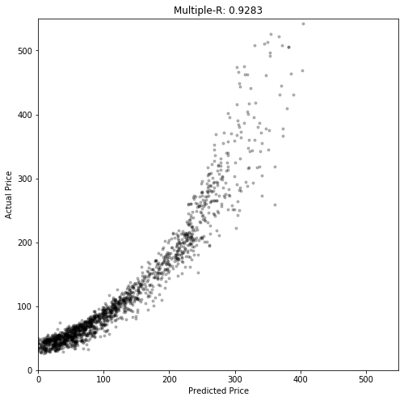

```python
y_pred = lr.predict(X_test)
plt.figure(figsize=(8,8))
plt.plot(y_pred, y_test, 'k.', alpha=0.25)
plt.xlim([0,550])
plt.ylim([0,550])
plt.xlabel('Predicted Price')
plt.ylabel('Actual Price')
plt.title('Multiple-R: %.4f' % np.corrcoef(y_pred, y_test)[0,1]);
```

#### The correlation between the predicted and actual values is 0.9283. This is a high correlation.